# Dumbbell lifting prediction

January 30, 2016

# Background

In this project, we will use data from accelerometers on the belt, forearm, arm, and dumbell of 6 participants. They were asked to perform dumbbell lifts correctly and incorrectly in 5 different ways. More information is available from the website here: http://groupware.les.inf.puc-rio.br/har (see the section on the Weight Lifting Exercise Dataset).

# Data

The training data for this project are available here: https://d396qusza40orc.cloudfront.net/predmachlearn/pml-training.csv The test data are available here: https://d396qusza40orc.cloudfront.net/predmachlearn/pml-testing.csv

The data for this project come from this source: http://groupware.les.inf.puc-rio.br/har.

# Load the data

We expect pml-training.csv and pml-training.csv files to be in the current folder.

```r
training  <- read.csv("pml-training.csv", header = TRUE, na.strings=c("NA","#DIV/0!"))
testing  <- read.csv("pml-testing.csv", header = TRUE)

training$classe <- as.factor(training$classe)
```

# Cleaning the data

Let’s explore the data set and choose the significant columns. We are not interested in any descriptive columns like user name, timestamps and window info.

```r
#explore the data set
colnames(training[,1:7])
```

```
## [1] "X"                    "user_name"            "raw_timestamp_part_1"
## [4] "raw_timestamp_part_2" "cvtd_timestamp"       "new_window"
## [7] "num_window"
```

The first 7 columns should be removed:

```r
#remove timestamps, user name and descriptory columns
training_clean <- subset(training,select=-c(X,user_name,raw_timestamp_part_1,raw_timestamp_part_2,cvtd_timestamp,new_window, num_window))
```

We also do not need any columns with NA values since we can not use them in Random Forest classifier.

```r
# build a feature list
features <- colnames(training_clean[, colSums(is.na(training_clean)) == 0])
features <- features[features != "classe"]
```

This is our initial list of features:

```r
print(features)
```

```
##  [1] "roll_belt"            "pitch_belt"           "yaw_belt"
##  [4] "total_accel_belt"     "gyros_belt_x"         "gyros_belt_y"
##  [7] "gyros_belt_z"         "accel_belt_x"         "accel_belt_y"
## [10] "accel_belt_z"         "magnet_belt_x"        "magnet_belt_y"
## [13] "magnet_belt_z"        "roll_arm"             "pitch_arm"
## [16] "yaw_arm"              "total_accel_arm"      "gyros_arm_x"
## [19] "gyros_arm_y"          "gyros_arm_z"          "accel_arm_x"
## [22] "accel_arm_y"          "accel_arm_z"          "magnet_arm_x"
## [25] "magnet_arm_y"         "magnet_arm_z"         "roll_dumbbell"
## [28] "pitch_dumbbell"       "yaw_dumbbell"         "total_accel_dumbbell"
## [31] "gyros_dumbbell_x"     "gyros_dumbbell_y"     "gyros_dumbbell_z"
## [34] "accel_dumbbell_x"     "accel_dumbbell_y"     "accel_dumbbell_z"
## [37] "magnet_dumbbell_x"    "magnet_dumbbell_y"    "magnet_dumbbell_z"
## [40] "roll_forearm"         "pitch_forearm"        "yaw_forearm"
## [43] "total_accel_forearm"  "gyros_forearm_x"      "gyros_forearm_y"
## [46] "gyros_forearm_z"      "accel_forearm_x"      "accel_forearm_y"
## [49] "accel_forearm_z"      "magnet_forearm_x"     "magnet_forearm_y"
## [52] "magnet_forearm_z"
```

# Cross validation of Random Forest model

We are going to use Random Forest classifier in our predictions. Let’s create a function which evaluates a model using a list of preselected features. We will be using this function in our feature selection chapter.

Number of folds in cross validation is 3.

```r
library(randomForest)
library(caret)
set.seed(7777)

evaluate_model <- function(features, data_set, num_trees){
    training_clean <- subset(data_set,select=c(features, "classe"))
    accuracy_validation <- 0

    i66 <- createDataPartition(training_clean$classe, p = .66, list = FALSE,times = 1)
    p1 <- training_clean[-i66,]
    p12 <- training_clean[i66,]
    i33 <- createDataPartition(p12$classe, p = .5, list = FALSE,times = 1)
    p2 <- p12[i33,]
    p3 <- p12[-i33,]

    model1 <- randomForest(classe~., data=rbind(p2,p3), ntree=num_trees)
    model2 <- randomForest(classe~., data=rbind(p1,p3), ntree=num_trees)
    model3 <- randomForest(classe~., data=rbind(p1,p2), ntree=num_trees)

    accuracy_validation <- accuracy_validation + confusionMatrix(predict(model1, newdata = p1), p1$classe)$overall[1]
    accuracy_validation <- accuracy_validation + confusionMatrix(predict(model2, newdata = p2), p2$classe)$overall[1]
    accuracy_validation <- accuracy_validation + confusionMatrix(predict(model3, newdata = p2), p2$classe)$overall[1]

    accuracy_validation <- accuracy_validation / 3

    return (list(1.0, accuracy_validation, model3))
}
```

# Build all features model

First, we build a classifier using all the features available.

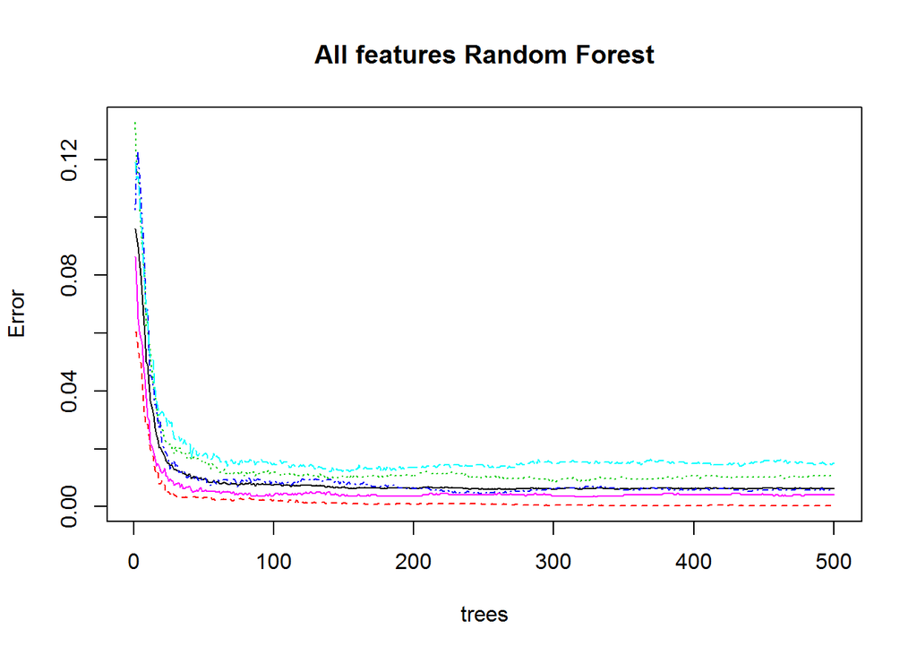

```r
eval_all_features <- evaluate_model(features, training_clean, 500)
plot(eval_all_features[[3]], main="All features Random Forest")
```

The plot of the error of the model gives us an idea about the optimum number of trees. We can use reduce the number of trees to 200 without impacting the overall accuracy of the model.

## The accuracy of all features model

```r
print (eval_all_features[[2]])
```

```
##  Accuracy
## 0.9961868
```

## The total number of features

```r
print (length(features))
```

```
## [1] 52
```

# Feature selection

We have 52 features in our list. Let’s try to do eliminate some highly correlated features and measure the impact of this on the overall validation accuracy.

First, we calculate correlation matrix

```r
#calculated correlation matrix
corr <- cor(training_clean[,features])
```

Second, we eliminate highly correlated features using a differnt cutoff values (from 0.5 to 1.0) and measuring the validation accuracy.

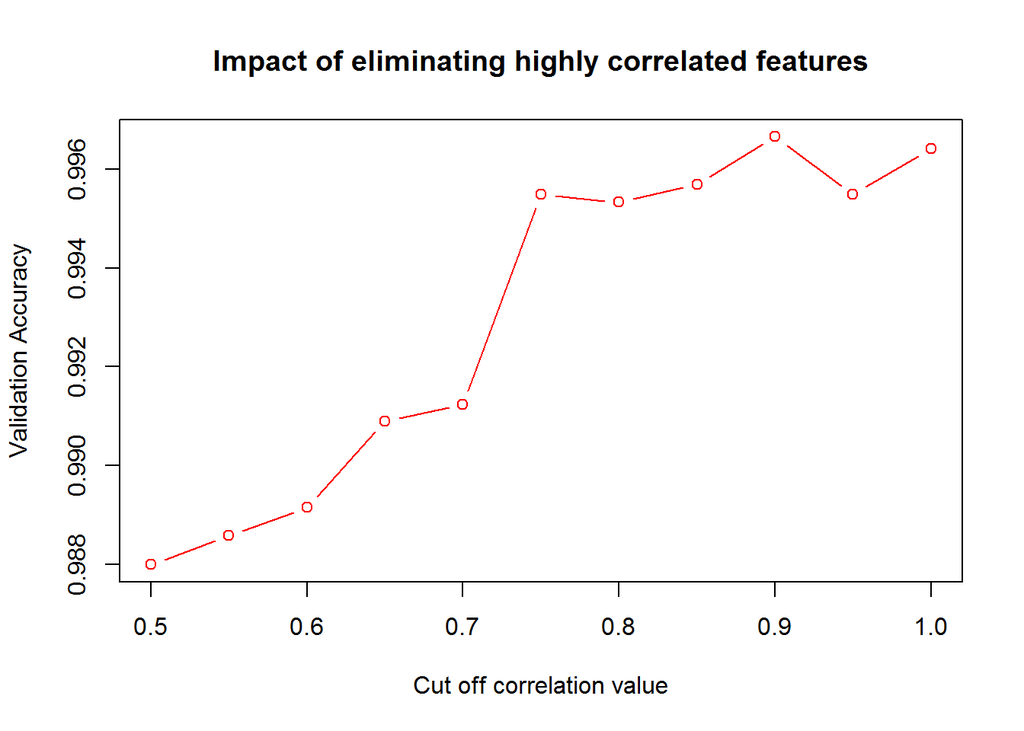

```r
cutoffs <- c()
cutoff_accuracy <- c()
for (i in 0:10){
    cutoff = 1.0-i*0.05
    correlated <- findCorrelation(corr, cutoff=cutoff)
    if(length(correlated) == 0)
        features_cutuoff <- features
    else
        features_cutuoff <- features[-correlated]
    eval <- evaluate_model(features_cutuoff, training_clean, 200)
    cutoffs <- c(cutoffs, cutoff)
    cutoff_accuracy <- c(cutoff_accuracy, eval[[2]])
}

plot(cutoffs, cutoff_accuracy, type='b', main = "Impact of eliminating highly correlated features",
     xlab = "Cut off correlation value", ylab = "Validation Accuracy", col = 'red')
```

Using this plot we can conclude that the optimum cutoff value is around 0.9

# Build the final model

Let’s build the final model with a reduced list of features using 0.9 cutoff value.

```r
correlated <- findCorrelation(corr, cutoff=0.9)
features_final <- features[-correlated]
```

## The number of features we eliminated:

```r
print (length(correlated))
```

```
## [1] 7
```

## Train final model

```r
eval_final <- evaluate_model(features_final, training_clean, 200)
model_final <- eval_final[[3]]
print(model_final)
```

```
##
## Call:
##  randomForest(formula = classe ~ ., data = rbind(p1, p2), ntree = num_trees)
##                Type of random forest: classification
##                      Number of trees: 200
## No. of variables tried at each split: 6
##
##         OOB estimate of  error rate: 0.6%
## Confusion matrix:
##      A    B    C    D    E class.error
## A 3731    5    2    0    1 0.002139610
## B   19 2518    7    0    0 0.010220126
## C    0   13 2278    2    0 0.006541648
## D    0    0   24 2130    1 0.011600928
## E    0    0    1    4 2412 0.002068680
```

```r
accuracy_final <- eval_final[[2]]
print (accuracy_final)
```

```
##  Accuracy
## 0.9960001
```

# Conlusion

```r
error_rate <-  100 * (1 - unname(accuracy_final))
print (error_rate)
```

```
## [1] 0.399992
```